# dashingWeather

Mohammad Hamdan

June 2, 2023

## Accessing the app

In order to download the app, you must run this code in the terminal on your computer. Don’t forget to first set it to the directory you want the app in! In the example, we’ll add the file to a folder on your desktop.

1. Set the directory to wherever you want to work. Use this template, but replace `<username>` with your username, and `<dashingWeatherpath>` with the path of the folder if you want to save the app file in.

```python
cd /Users/<username>/Desktop/<dashingWeatherpath>
```

2. Then copy this (don’t change anything):

```python
curl -o app.py https://raw.githubusercontent.com/Programming-The-Next-Step-2023/dashingWeather/main/dashingWeather/module/app.py
```

3. Start running the app using:

```python
python app.py
```

4. Your terminal should then tell you where the app is being broadcasted to. This should be a series of numbers in this format: http://XXX.X.X.X:XXXX/. Copy the numbers into the search bar on your browser, and you should be able to use `dashingWeather`.

If you’re ever re-running it, you only need steps 1, 3 and 4.

## Launch

At launch, the user is greeted by the current conditions for Amsterdam, The Netherlands (which is where the app was developed). Data is displayed in metric measurements (again, to reflect where the app was made), so temperatures are presented in degrees Celsius (°C), and wind speeds are presented in meters per second. The world map is set to display world temperatures.

[figure not shown]

## Features

### City change

From there the user has the freedom to to look up weather conditions in any city of their choice, where the only limits are their speed of typing. They can go about this by typing in the name of a city in the search bar and clicking the on-screen `Go` button, or the `Enter` button their keyboard. Let’s look at a city on a different continent, perhaps Cairo, Egypt:

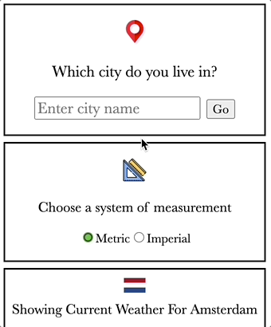

The entire webpage is then instantly updated to show the metrics for Cairo from right now and for the next few days.

[figure not shown]

This includes a change in the dynamic icon: a flag icon which also updates whenever a new city (or a city in a different country) is typed in! Notice how the Dutch flag switched to the Egyptian flag?

### Measurement change

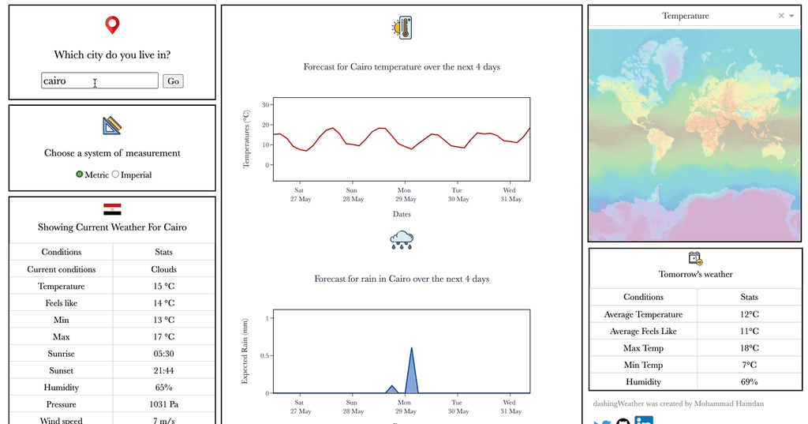

### Interactive Plots

The temperature and rain plots are interactive, allowing the user to zoom in and out and even save them as `.png` files if they wish.

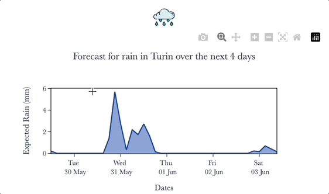

### World view

Last but not least, using the app the user can access colourful images that tell them about the state of the weather across the world today:

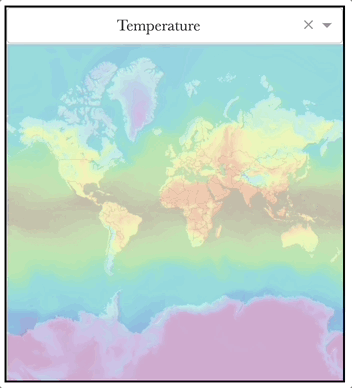

For example, they can see how temperature is distributed across the globe, or how windy it is or where it will rain now. It is currently late spring in the northern hemisphere so there will be warmer temperatures, less wind and rain above the equator, and vice versa below it. However, with climate change there is no guarantee, so if something seems off on the app (like rain in Cairo but not in Amsterdam), blame climate change, not me!

## Contact

Lastly, at the bottom right of the screen, users are presented with different ways to contact the developer - simply by clicking the app icon of their interest: they can contact me through Twitter or Linkedin, and by checking out my Github they can also find the code that runs the app.

[figure not shown]